# Group Project 0

Adlan

2025-10-04

Here, we are trying to predict the closing price of stocks using a linear regression.

Firstly, let’s setup the key packages needed.

```r
# This R environment comes with many helpful analytics packages installed
# It is defined by the kaggle/rstats Docker image: https://github.com/kaggle/docker-rstats
# For example, here's a helpful package to load

library(tidyverse) # metapackage of all tidyverse packages
library(pheatmap)
library(car)
library(lmtest)
# Input data files are available in the read-only "../input/" directory
# For example, running this (by clicking run or pressing Shift+Enter) will list all files under the input directory

list.files(path = "../input")
```

```
## character(0)
```

```r
# You can write up to 20GB to the current directory (/kaggle/working/) that gets preserved as output when you create a version using "Save & Run All"
# You can also write temporary files to /kaggle/temp/, but they won't be saved outside of the current session
```

Here, we load the CSV file and look at the initial structure of the data.

```r
#read the file
data <- read.csv("https://media.githubusercontent.com/media/railtonjamesl-collab/ds-project/refs/heads/main/dataset/finance_economics_dataset.csv")
str(data)
```

```
## 'data.frame':    3000 obs. of  24 variables:
##  $ Date                                 : chr  "2000-01-01" "2000-01-02" "2000-01-03" "2000-01-04" ...
##  $ Stock.Index                          : chr  "Dow Jones" "S&P 500" "Dow Jones" "Dow Jones" ...
##  $ Open.Price                           : num  2129 2047 1988 4625 1998 ...
##  $ Close.Price                          : num  2138 2036 1985 4660 1982 ...
##  $ Daily.High                           : num  2144 2083 2022 4665 2044 ...
##  $ Daily.Low                            : num  2101 2010 1978 4595 1966 ...
##  $ Trading.Volume                       : int  2670411 690220415 315284661 13098297 385306746 82664194 653722138 423890033 867172199 174582201 ...
##  $ GDP.Growth....                       : num  -0.37 3.19 5.54 10 1.53 1.42 7.64 7.08 5.97 1.95 ...
##  $ Inflation.Rate....                   : num  6.06 4.95 9.13 3.77 2.2 6.08 6.24 4.39 4.87 9.6 ...
##  $ Unemployment.Rate....                : num  6.1 6.62 2.6 2.2 8.2 ...
##  $ Interest.Rate....                    : num  6.06 2.19 0.82 3.71 4.56 1.09 8.24 3.77 9.18 1.97 ...
##  $ Consumer.Confidence.Index            : int  114 101 92 112 99 88 91 66 92 98 ...
##  $ Government.Debt..Billion.USD.        : int  27271 16160 29962 12745 22293 15880 17830 20092 27069 3940 ...
##  $ Corporate.Profits..Billion.USD.      : int  1645 1008 4562 4183 3440 2525 3318 2265 1113 3306 ...
##  $ Forex.USD.EUR                        : num  1.04 1 0.83 0.95 1.43 1.39 0.92 1.06 1.02 0.9 ...
##  $ Forex.USD.JPY                        : num  119.9 98.2 80.1 149.2 113.7 ...
##  $ Crude.Oil.Price..USD.per.Barrel.     : num  47.2 52.8 78.8 28.2 92.2 ...
##  $ Gold.Price..USD.per.Ounce.           : num  1052 1958 2339 1309 2210 ...
##  $ Real.Estate.Index                    : num  390 346 439 213 405 ...
##  $ Retail.Sales..Billion.USD.           : int  2229 4156 340 8456 1596 403 4874 1011 5193 6147 ...
##  $ Bankruptcy.Rate....                  : num  2.12 1.4 0.79 4.22 2.21 0.82 9.55 7.33 5.18 7.43 ...
##  $ Mergers...Acquisitions.Deals         : int  3 21 48 16 34 45 31 37 30 24 ...
##  $ Venture.Capital.Funding..Billion.USD.: num  76.64 5.67 39.43 12.83 86.37 ...
##  $ Consumer.Spending..Billion.USD.      : int  4589 10101 13665 5192 10688 8613 1303 3771 13164 13774 ...
```

Now, let’s ensure that we do not have any blank entries or NAs.

```r
#Check the # NAs for each column, and notice that we don't have any.
col_na <- colSums(is.na(data))
paste("The no. of NAs is:", sum(col_na[col_na > 0]))
```

```
## [1] "The no. of NAs is: 0"
```

Let’s now convert data like the stock index or time to numbers so that we can actually use them in calculations.

```r
#Transform both categorical column "Stock.index", and time-data "Date" to integer
# store it to reuse later for certain functions
Stock.Index <- data$Stock.Index

data$Stock.Index <- as.integer(as.factor(data$Stock.Index))
data$Date <- as.integer(as.factor(data$Date))
```

One useful step is to look at how the data is correlated. As expected, our opening price, closing price, daily high and daily low are all perfectly correlated.

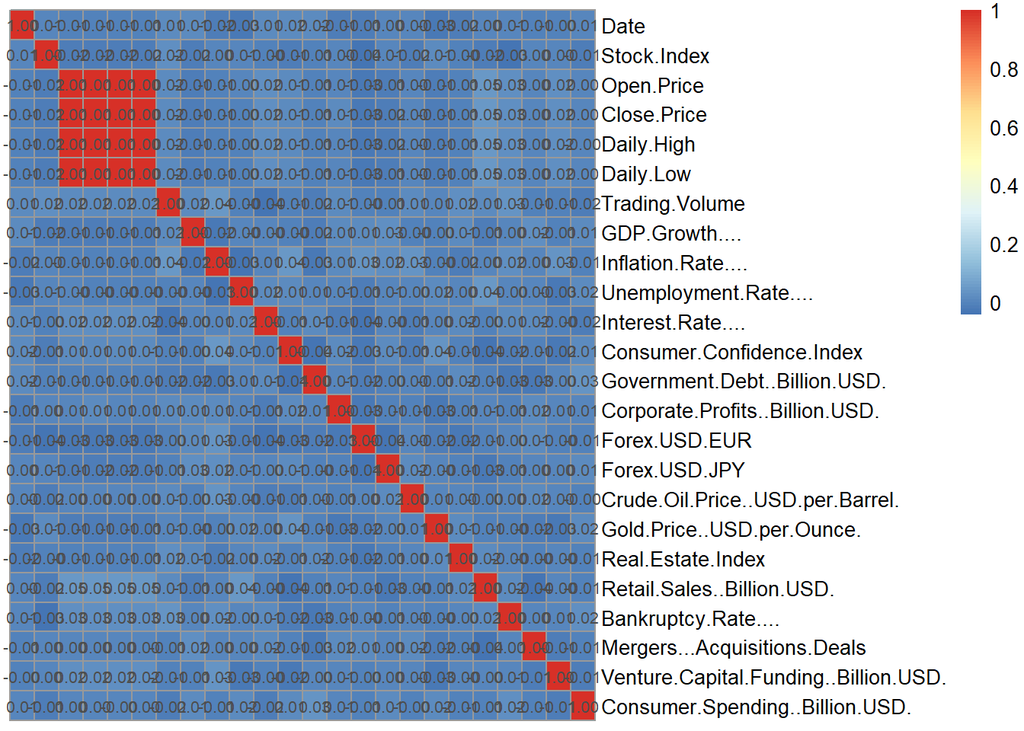

```r
#Check their correlation matrix:
#As expected, all 4 Open.Price, Close.Price, Daily.High, Daily.Low are all (perfectly) positively correlated with one another.
cor.matrix <- cor(data)
pheatmap(cor.matrix, display_numbers = TRUE,
         show_colnames = FALSE, cluster_rows = FALSE, cluster_cols = FALSE)
```

Now, let’s split the data in to a training set (70%) and a testing set (30%).

```r
# cross validation (70/30)
set.seed(500)

# convert Stock.Index back to a factor
data$Stock.Index <- as.factor(Stock.Index)

samp <- sample(1:nrow(data), floor(0.7 * nrow(data)), replace = FALSE)
X_train <- data[samp, ] %>% select(-"Close.Price")
Y_train <- data[samp, "Close.Price"]
X_test <- data[-samp, ] %>% select(-"Close.Price")
Y_test <- data[-samp, "Close.Price"]
```

Here, we create our initial regression.

```r
#We first fit a linear regression model using all predictors.
fit.full <- lm(Y_train ~ ., data=X_train)
summary(fit.full)$adj.r.squared
```

```
## [1] 0.9997896
```

Adjusted R squared is very high, we’ll try looking at other metrics too. We now perform all of backward elimination, forward selection, and stepwise regression, to both get rid of predictors with high p-values and minimize our AIC values.

```r
# define intercept model
fit.simple <- lm(Y_train ~ 1, data=X_train)

fit.backward <- stats::step(fit.full, direction = "backward", trace=0)
fit.forward <- stats::step(fit.simple, scope=list(upper=fit.full, lower=fit.simple),
                          direction = "forward", trace=0)
fit.stepwise <- stats::step(fit.simple, scope=list(upper=fit.full, lower=fit.simple),
                          direction = "both", trace=0)

data.frame(AIC = c(extractAIC(fit.backward)[2], extractAIC(fit.forward)[2], extractAIC(fit.stepwise)[2]),
          row.names = c("Backward Elimination", "Forward Selection", "Stepwise Regression"))
```

```
##                           AIC
## Backward Elimination 11841.66
## Forward Selection    11841.66
## Stepwise Regression  11841.66
```

It turns out that they all yielded the same model. We now are left with only 8 predictors (including the intercept).

```r
summary(fit.stepwise)$coefficients
```

```
##                                      Estimate   Std. Error    t value
## (Intercept)                      7.0748226469 2.802965e+00   2.524049
## Daily.Low                        0.6644990547 1.736336e-02  38.270182
## Daily.High                       0.6773832658 1.817127e-02  37.277707
## Open.Price                      -0.3420630118 2.100055e-02 -16.288287
## Forex.USD.JPY                   -0.0735928373 1.797905e-02  -4.093255
## Consumer.Spending..Billion.USD.  0.0001868821 8.649697e-05   2.160563
## Date                            -0.0008797522 4.212998e-04  -2.088186
## Unemployment.Rate....            0.1397124436 9.775432e-02   1.429220
##                                      Pr(>|t|)
## (Intercept)                      1.167463e-02
## Daily.Low                       2.280245e-243
## Daily.High                      1.106554e-233
## Open.Price                       2.980558e-56
## Forex.USD.JPY                    4.415158e-05
## Consumer.Spending..Billion.USD.  3.084235e-02
## Date                             3.690176e-02
## Unemployment.Rate....            1.530903e-01
```

We will check if there are any problems with multicollinearity, using VIF.

```r
data.frame(vif(fit.stepwise))
```

```
##                                 vif.fit.stepwise.
## Daily.Low                             3020.519896
## Daily.High                            3310.768921
## Open.Price                            4421.784830
## Forex.USD.JPY                            1.001651
## Consumer.Spending..Billion.USD.          1.001414
## Date                                     1.001374
## Unemployment.Rate....                    1.005779
```

The high VIF values are understandable as we know they are perfectly correlated. Let’s move and check their MSE and MSPE.